# The Barney Stinson’s 3-Day Rule Strategy

Victor Anton, Imholz Chris

20.12.2024

## 1 **Introduction**

In the world of stock trading, timing is everything—just like in dating. So, in true **Barney Stinson** fashion, we decided to test the legendary **3-Day Rule** on stocks, because if it works for love, why not try it for financial markets? According to **Barney**, you should wait three days before calling a girl. But what if you applied this rule to stocks? That’s exactly what we set out to find out!

In this project, we borrowed from **Barney’s 3-Day Rule**—waiting three days after a significant price drop before making a move. Just like Barney would give a girl three days to call back, we waited three trading days to see if a stock could “call back” with a recovery. Of course, we added a twist: instead of relying on gut feelings, we introduced predictive models like **ARIMA** to try and forecast whether that stock would return our affection—or leave us high and dry.

As we venture through this journey of “stock dating,” we’ll explore whether the **3-Day Rule** can really lead to gains or if we’re just chasing after a market that’s playing hard to get. Spoiler alert: We may have had a few “bad dates” along the way, but who knows? With some fine-tuning, we might just find our perfect match.

So, grab your suits, put on your best game face, and let’s dive into this adventure where **Barney’s Rule** meets financial forecasting—because in trading, like in love, it’s all about taking risks and waiting for the right moment.

[figure not shown]

## 3 **Data Preparation**

### 3.1 **Load Required Libraries**

In this report the following libraries are used.

**Click to see all libraries**

```r
if (!require("quantmod")) install.packages("quantmod")
if (!require("dplyr")) install.packages("dplyr")
if (!require("ggplot2")) install.packages("ggplot2")
if (!require("forecast")) install.packages("forecast")
if (!require("TTR")) install.packages("TTR")


library(quantmod)
library(dplyr)
library(forecast)
library(TTR)
library(knitr)
opts_chunk$set(echo = TRUE, eval = TRUE, warning = FALSE, message = FALSE)
```

### 3.2 **Column Descriptions**

The following column names appear in the downloaded data. `[SYMBOL]` represents the stock ticker:

| **Column** | **Description** |
| --- | --- |
| `[SYMBOL].Open` | Opening price of the stock on a given trading day. |
| `[SYMBOL].High` | Highest intraday price of the stock. |
| `[SYMBOL].Low` | Lowest intraday price of the stock. |
| `[SYMBOL].Close` | Closing price of the stock at the end of the trading day. |
| `[SYMBOL].Volume` | Number of shares traded during the trading day. |
| `[SYMBOL].Adjusted` | Adjusted closing price accounting for dividends, splits, and other adjustments. |

This section outlines the process of retrieving historical stock price data for companies listed in the Swiss Market Index (SMI) and the S&P 500 index. It specifies the relevant stock symbols and employs a custom function to download the data from Yahoo Finance. The function also includes error handling to manage any issues during the download process. Once the data is downloaded, it is saved as an RDS file to ensure efficient future access and prevent redundant downloads.

**Click to see data for UBS**

```
##            UBSG.SW.Open UBSG.SW.High UBSG.SW.Low UBSG.SW.Close UBSG.SW.Volume
## 2022-01-03       16.425       16.650      16.380         16.63        4570356
## 2022-01-04       16.700       17.095      16.700         17.04        9988997
## 2022-01-05       17.060       17.160      17.000         17.15        6879678
## 2022-01-06       17.060       17.425      16.970         17.34       11622944
## 2022-01-07       17.500       17.875      17.465         17.78       15152280
##            UBSG.SW.Adjusted
## 2022-01-03         15.24598
## 2022-01-04         15.62186
## 2022-01-05         15.72271
## 2022-01-06         15.89690
## 2022-01-07         16.30028
```

### 3.3 **Visualizing Adjusted Stock Prices Over Time**

This section introduces a function for visualizing the adjusted stock prices of specific companies over time. The function ensures that the required adjusted price data is available and generates a line chart displaying price trends. The chart is designed with clear labels, titles, and formatting to enhance readability. This visualization aids in understanding the historical performance of the stocks and identifying trends or patterns that could inform investment strategies.

In this example, we plot the UBS stock prices.

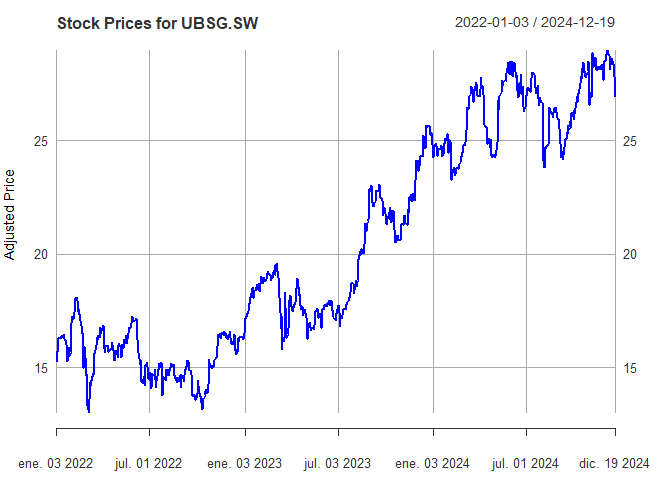

### 3.4 **Calculating Daily Percentage Price Changes for SMI Stocks**

This section calculates the daily percentage price changes for each stock’s adjusted closing price in the Swiss Market Index (SMI). A utility function is applied across all stocks to compute these changes and store them in a new column. This transformation prepares the data for identifying significant events, such as large price changes, which are essential for strategy development.

**Click to see percentage difference data for “UBSG.SW”**

```r
# The `calc_percent_diff` function calculates the percentage change in the adjusted closing price for a given stock.
calc_percent_diff <- function(stock_data, symbol) {
  if (!is.null(stock_data[[symbol]])) {

    close_col <- paste0(symbol, ".Adjusted")
    if (close_col %in% colnames(stock_data[[symbol]])) {

      close_prices <- stock_data[[symbol]][, close_col]
      percent_diff <- (close_prices / lag(close_prices) - 1) * 100

      percent_diff_col <- paste0(symbol, ".Percent_Diff")

      stock_data[[symbol]] <- as.data.frame(stock_data[[symbol]])

      stock_data[[symbol]][, percent_diff_col] <- percent_diff



      return(stock_data[[symbol]])
    } else {
      cat("Close column not found for:", symbol, "\n")
      return(NULL)
    }
  } else {
    cat("No data available for:", symbol, "\n")
    return(NULL)
  }
}

# The `calc_all_percent_diff` function applies the `calc_percent_diff` function to a list of stock symbols.
calc_all_percent_diff <- function(stock_data, symbols) {
  modified_stock_data <- stock_data  # Copy the original list structure
  for (symbol in symbols) {
    modified_stock_data[[symbol]] <- calc_percent_diff(stock_data, symbol)
  }
  return(modified_stock_data)
}

# Calculate percentage differences for all stocks in the SMI.
smi_percent_diff <- calc_all_percent_diff(smi_data, smi_symbols)

# Example: View the first few rows of percentage difference data for "UBSG.SW".
head(smi_percent_diff[["UBSG.SW"]])
```

```
##            UBSG.SW.Open UBSG.SW.High UBSG.SW.Low UBSG.SW.Close UBSG.SW.Volume
## 2022-01-03       16.425       16.650      16.380         16.63        4570356
## 2022-01-04       16.700       17.095      16.700         17.04        9988997
## 2022-01-05       17.060       17.160      17.000         17.15        6879678
## 2022-01-06       17.060       17.425      16.970         17.34       11622944
## 2022-01-07       17.500       17.875      17.465         17.78       15152280
## 2022-01-10       17.840       17.960      17.625         17.78       10876949
##            UBSG.SW.Adjusted UBSG.SW.Percent_Diff
## 2022-01-03         15.24598                   NA
## 2022-01-04         15.62186            2.4654441
## 2022-01-05         15.72271            0.6455275
## 2022-01-06         15.89690            1.1078732
## 2022-01-07         16.30028            2.5374911
## 2022-01-10         16.30028            0.0000000
```

## 4 **Implementation of the Strategy**

The strategy is implemented in several steps to identify and act on significant stock price movements systematically:

**3. Holding Period**: The stocks are held for 30 trading days, allowing for potential recovery.

**4. Return Calculation**: Returns are calculated based on the buy price and the sell price after 30 days.

Each step is supported by specific code implementations, which are detailed below.

### 4.1 **Identifying Events with ≥ 5% Price Changes**

$$\text{Percentage Change} = \left(\frac{\text{Current
Price}}{\text{Previous Price}} - 1\right) \times 100$$

This calculation is applied across all stocks in the dataset, and the results are stored in a new column, `[SYMBOL].Percent_Diff`. A threshold filter is then applied to flag events where the percentage change is lower or equal to -5%.

**Click to see all identified events for UBS**

```
##            UBSG.SW.Adjusted UBSG.SW.Percent_Diff Event
## 2022-01-03         15.24598                   NA    NA
## 2022-01-04         15.62186           2.46544412 FALSE
## 2022-01-05         15.72271           0.64552750 FALSE
## 2022-01-06         15.89690           1.10787317 FALSE
## 2022-01-07         16.30028           2.53749107 FALSE
## 2022-01-10         16.30028           0.00000000 FALSE
## 2022-01-11         16.33695           0.22496969 FALSE
## 2022-01-12         16.38279           0.28057506 FALSE
## 2022-01-13         16.44696           0.39173166 FALSE
## 2022-01-14         16.33236          -0.69678051 FALSE
## 2022-01-17         16.48363           0.92618566 FALSE
## 2022-01-18         16.27277          -1.27919261 FALSE
## 2022-01-19         16.19027          -0.50703149 FALSE
## 2022-01-20         16.20860           0.11324918 FALSE
## 2022-01-21         16.03441          -1.07466779 FALSE
## 2022-01-24         15.28266          -4.68838955 FALSE
## 2022-01-25         15.52102           1.55968536 FALSE
## 2022-01-26         15.90148           2.45126150 FALSE
## 2022-01-27         15.78230          -0.74948832 FALSE
## 2022-01-28         15.52560          -1.62649088 FALSE
## 2022-01-31         15.67687           0.97432562 FALSE
## 2022-02-01         16.93744           8.04092688 FALSE
## 2022-02-02         17.23539           1.75912532 FALSE
## 2022-02-03         17.26289           0.15957846 FALSE
## 2022-02-04         17.13454          -0.74348724 FALSE
## 2022-02-07         17.42333           1.68537963 FALSE
## 2022-02-08         17.69378           1.55223282 FALSE
## 2022-02-09         18.07882           2.17616625 FALSE
## 2022-02-10         18.10633           0.15212307 FALSE
## 2022-02-11         17.97798          -0.70885393 FALSE
## 2022-02-14         17.47834          -2.77918588 FALSE
## 2022-02-15         17.57918           0.57696240 FALSE
## 2022-02-16         17.34998          -1.30379546 FALSE
## 2022-02-17         17.18038          -0.97753086 FALSE
## 2022-02-18         17.09787          -0.48024595 FALSE
## 2022-02-21         16.65782          -2.57373489 FALSE
## 2022-02-22         16.52030          -0.82553434 FALSE
## 2022-02-23         16.33236          -1.13763403 FALSE
## 2022-02-24         14.98929          -8.22340124  TRUE
```

[output cut: 46 more lines]

```
## 2022-05-04         16.08350           0.50135138 FALSE
## 2022-05-05         15.97968          -0.64555260 FALSE
## 2022-05-06         15.95136          -0.17719723 FALSE
## 2022-05-09         15.44167          -3.19527181 FALSE
## 2022-05-10         15.69180           1.61981096 FALSE
## 2022-05-11         16.01271           2.04510235 FALSE
## 2022-05-12         15.84282          -1.06100195 FALSE
## 2022-05-13         16.26283           2.65116483 FALSE
## 2022-05-16         16.07406          -1.16074657 FALSE
## 2022-05-17         16.44217           2.29006701 FALSE
## 2022-05-18         16.31947          -0.74626182 FALSE
## 2022-05-19         16.09294          -1.38809706 FALSE
## 2022-05-20         16.25812           1.02640229 FALSE
## 2022-05-23         16.77724           3.19303195 FALSE
## 2022-05-24         16.78197           0.02813744 FALSE
```

### 4.2 **Buying the Stock 3 Days After the Even**

**Click to see buy dates**

```
##            UBSG.SW.Open UBSG.SW.High UBSG.SW.Low UBSG.SW.Close UBSG.SW.Volume
## 2022-01-03       16.425       16.650      16.380        16.630        4570356
## 2022-01-04       16.700       17.095      16.700        17.040        9988997
## 2022-01-05       17.060       17.160      17.000        17.150        6879678
## 2022-01-06       17.060       17.425      16.970        17.340       11622944
## 2022-01-07       17.500       17.875      17.465        17.780       15152280
## 2022-01-10       17.840       17.960      17.625        17.780       10876949
## 2022-01-11       17.830       17.925      17.730        17.820        8193928
## 2022-01-12       17.895       17.975      17.700        17.870        8162261
## 2022-01-13       17.830       18.000      17.815        17.940        5993146
## 2022-01-14       17.820       17.980      17.720        17.815        6290114
## 2022-01-17       17.885       17.990      17.870        17.980        6323774
## 2022-01-18       17.880       17.945      17.725        17.750        8239961
## 2022-01-19       17.730       17.840      17.575        17.660        7293279
## 2022-01-20       17.550       17.725      17.505        17.680        6547998
## 2022-01-21       17.440       17.715      17.375        17.490       12795643
## 2022-01-24       17.570       17.570      16.575        16.670       13021542
## 2022-01-25       16.750       17.060      16.670        16.930       10147253
## 2022-01-26       17.050       17.500      17.045        17.345        7017701
## 2022-01-27       17.180       17.460      17.100        17.215        9858531
## 2022-01-28       17.230       17.265      16.705        16.935        9976661
## 2022-01-31       17.150       17.285      17.030        17.100       12006326
## 2022-02-01       18.050       18.475      17.960        18.475       23528059
## 2022-02-02       18.500       18.930      18.455        18.800       19878444
## 2022-02-03       18.830       19.100      18.750        18.830       14798979
## 2022-02-04       18.900       18.985      18.455        18.690       10302209
## 2022-02-07       18.755       19.005      18.645        19.005       11354111
## 2022-02-08       19.020       19.335      19.010        19.300       12372440
## 2022-02-09       19.400       19.790      19.305        19.720       13024990
## 2022-02-10       19.520       19.900      19.510        19.750       14427270
## 2022-02-11       19.465       19.735      19.420        19.610       10909790
## 2022-02-14       19.040       19.165      18.800        19.065       13577591
## 2022-02-15       18.700       19.225      18.555        19.175       10354149
## 2022-02-16       19.300       19.340      18.705        18.925        9755735
## 2022-02-17       18.900       18.935      18.580        18.740        9238626
## 2022-02-18       18.725       18.890      18.595        18.650       10102466
## 2022-02-21       18.620       18.785      18.065        18.170        8574739
## 2022-02-22       17.585       18.185      17.300        18.020       14867844
## 2022-02-23       18.090       18.205      17.805        17.815        8327922
## 2022-02-24       16.885       17.100      16.065        16.350       24469646
```

[output cut: 147 more lines]

```
## 2022-05-04         16.08350           0.50135138 FALSE 2022-05-04       <NA>
## 2022-05-05         15.97968          -0.64555260 FALSE 2022-05-05       <NA>
## 2022-05-06         15.95136          -0.17719723 FALSE 2022-05-06       <NA>
## 2022-05-09         15.44167          -3.19527181 FALSE 2022-05-09       <NA>
## 2022-05-10         15.69180           1.61981096 FALSE 2022-05-10       <NA>
## 2022-05-11         16.01271           2.04510235 FALSE 2022-05-11       <NA>
## 2022-05-12         15.84282          -1.06100195 FALSE 2022-05-12       <NA>
## 2022-05-13         16.26283           2.65116483 FALSE 2022-05-13       <NA>
## 2022-05-16         16.07406          -1.16074657 FALSE 2022-05-16       <NA>
## 2022-05-17         16.44217           2.29006701 FALSE 2022-05-17       <NA>
## 2022-05-18         16.31947          -0.74626182 FALSE 2022-05-18       <NA>
## 2022-05-19         16.09294          -1.38809706 FALSE 2022-05-19       <NA>
## 2022-05-20         16.25812           1.02640229 FALSE 2022-05-20       <NA>
## 2022-05-23         16.77724           3.19303195 FALSE 2022-05-23       <NA>
## 2022-05-24         16.78197           0.02813744 FALSE 2022-05-24       <NA>
```

### 4.3 **Holding the Stock for 30 Days**

After the stock is purchased, it is held for a fixed period of 30 trading days. This duration is chosen based on the hypothesis that prices will recover following the initial overreaction, allowing for potential capital appreciation during this window.

#### 4.3.1 Calculating Returns

To evaluate the strategy’s performance, the return on each trade is calculated as:

$$\text{Return} = \frac{\text{Sell Price} - \text{Buy Price}}{\text{Buy
Price}}$$

Where:

- The **Buy Price** is the adjusted closing price on the calculated buy date.
- The **Sell Price** is the adjusted closing price 30 days after the buy date.

These returns are stored for analysis and aggregated to assess the overall profitability of the strategy.

**Click to see holding periods**

```r
# Function to calculate returns
calculate_returns <- function(stock_data, symbol) {
  if (!is.null(stock_data[[symbol]])) {
    stock_data[[symbol]] <- as.data.frame(stock_data[[symbol]])
    adjusted_col <- paste0(symbol, ".Adjusted")  # Adjusted close price

    if (adjusted_col %in% colnames(stock_data[[symbol]])) {
      # Calculate return
      stock_data[[symbol]]$Return <- ifelse(
        !is.na(stock_data[[symbol]]$Buy_Date),  # If a buy date exists
        {
          # Purchase price (close price at Buy_Date)
          buy_price <- lag(stock_data[[symbol]][, adjusted_col], 3)
          # Selling price (close price after 30 days)
          sell_price <- lead(stock_data[[symbol]][, adjusted_col], 30)
          # Calculate return
          (sell_price - buy_price) / buy_price
        },
        NA  # No return if no buy date exists
      )
      return(stock_data[[symbol]])
    } else {
      cat("Adjusted price column not found for:", symbol, "\n")
      return(NULL)
    }
  } else {
    cat("No data available for:", symbol, "\n")
    return(NULL)
  }
}

# For-loop to calculate returns for each symbol
smi_with_returns <- list()

for (i in seq_along(smi_with_buy_dates)) {
  symbol <- smi_symbols[i]  # The current symbol
  smi_with_returns[[symbol]] <- calculate_returns(stock_data = smi_with_buy_dates, symbol = symbol)
}

head(smi_with_returns[["UBSG.SW"]], 100)
```

```
##            UBSG.SW.Open UBSG.SW.High UBSG.SW.Low UBSG.SW.Close UBSG.SW.Volume
## 2022-01-03       16.425       16.650      16.380        16.630        4570356
## 2022-01-04       16.700       17.095      16.700        17.040        9988997
## 2022-01-05       17.060       17.160      17.000        17.150        6879678
## 2022-01-06       17.060       17.425      16.970        17.340       11622944
## 2022-01-07       17.500       17.875      17.465        17.780       15152280
## 2022-01-10       17.840       17.960      17.625        17.780       10876949
## 2022-01-11       17.830       17.925      17.730        17.820        8193928
## 2022-01-12       17.895       17.975      17.700        17.870        8162261
## 2022-01-13       17.830       18.000      17.815        17.940        5993146
## 2022-01-14       17.820       17.980      17.720        17.815        6290114
## 2022-01-17       17.885       17.990      17.870        17.980        6323774
## 2022-01-18       17.880       17.945      17.725        17.750        8239961
## 2022-01-19       17.730       17.840      17.575        17.660        7293279
## 2022-01-20       17.550       17.725      17.505        17.680        6547998
## 2022-01-21       17.440       17.715      17.375        17.490       12795643
## 2022-01-24       17.570       17.570      16.575        16.670       13021542
## 2022-01-25       16.750       17.060      16.670        16.930       10147253
## 2022-01-26       17.050       17.500      17.045        17.345        7017701
## 2022-01-27       17.180       17.460      17.100        17.215        9858531
## 2022-01-28       17.230       17.265      16.705        16.935        9976661
## 2022-01-31       17.150       17.285      17.030        17.100       12006326
## 2022-02-01       18.050       18.475      17.960        18.475       23528059
## 2022-02-02       18.500       18.930      18.455        18.800       19878444
## 2022-02-03       18.830       19.100      18.750        18.830       14798979
## 2022-02-04       18.900       18.985      18.455        18.690       10302209
## 2022-02-07       18.755       19.005      18.645        19.005       11354111
## 2022-02-08       19.020       19.335      19.010        19.300       12372440
## 2022-02-09       19.400       19.790      19.305        19.720       13024990
## 2022-02-10       19.520       19.900      19.510        19.750       14427270
## 2022-02-11       19.465       19.735      19.420        19.610       10909790
## 2022-02-14       19.040       19.165      18.800        19.065       13577591
## 2022-02-15       18.700       19.225      18.555        19.175       10354149
## 2022-02-16       19.300       19.340      18.705        18.925        9755735
## 2022-02-17       18.900       18.935      18.580        18.740        9238626
## 2022-02-18       18.725       18.890      18.595        18.650       10102466
## 2022-02-21       18.620       18.785      18.065        18.170        8574739
## 2022-02-22       17.585       18.185      17.300        18.020       14867844
## 2022-02-23       18.090       18.205      17.805        17.815        8327922
## 2022-02-24       16.885       17.100      16.065        16.350       24469646
```

[output cut: 248 more lines]

```
## 2022-05-04          NA
## 2022-05-05          NA
## 2022-05-06          NA
## 2022-05-09          NA
## 2022-05-10          NA
## 2022-05-11          NA
## 2022-05-12          NA
## 2022-05-13          NA
## 2022-05-16          NA
## 2022-05-17          NA
## 2022-05-18          NA
## 2022-05-19          NA
## 2022-05-20          NA
## 2022-05-23          NA
## 2022-05-24          NA
```

### 4.4 **Summary of the Results**

The performance of the strategy is quantified using several key metrics:

- **Average Return**: The average return across all transactions.
- **Median Return**: The median return, which helps avoid distortion due to outliers.
- **Positive vs. Negative Returns**: The proportion of positive returns relative to negative returns.
- **Maximum and Minimum Return**: Identification of the maximum and minimum returns across the trades.
- **Total Return**: The total return when applying the strategy to the entire portfolio.

These metrics are calculated using the following dataset, which includes event dates, buy dates, and returns:

| Event_Date | Buy_Date | Return |
| --- | --- | --- |
| 2022-01-03 | 2022-01-03 |  |
| … | … | … |
| 2022-02-24 | 2022-02-24 | -0.0597 |
| 2022-03-01 | 2022-03-01 | 0.0585 |
| 2022-03-04 | 2022-03-04 | 0.0813 |
| … | … | … |

The returns are calculated by comparing the buy and sell prices, with the strategy’s overall performance aggregated to assess profitability.

With an **average of return** of **-0.06** and a **total return** of **-7.98**.

**Click to see summary results**

```
## $average_return
## [1] -0.05870574
##
## $median_return
## [1] -0.05914732
##
## $positive_ratio
## [1] 0.2647059
##
## $max_return
## [1] 0.1744897
##
## $min_return
## [1] -0.3717201
##
## $total_return
## [1] -7.983981
```

### 4.5 **Visualization of Strategy Performance**

This section focuses on visualizing the returns generated by the implemented strategy to gain insights into its performance. Two key visualizations are included:

#### 4.5.1 **Distribution of Returns**

The histogram shows the frequency of positive and negative returns, providing a clear overview of the return distribution. This helps identify whether the strategy generates more positive or negative returns and highlights the variability of returns.

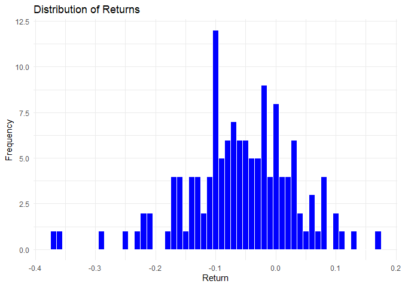

#### 4.5.2 **Returns Over Time**

The scatter plot shows how returns evolve over time, highlighting any trends, clusters, or patterns in the strategy’s performance.

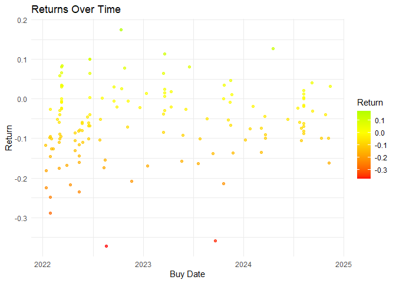

#### 4.5.3 **Implementation and Benchmarking of the Buy-and-Hold Strategy**

This section focuses on implementing the **Buy-and-Hold strategy** as a benchmark for evaluating the trading strategy. For each stock in the SMI, the strategy calculates the return by comparing the adjusted closing price at the start date to the adjusted closing price at the end date. The returns are averaged across all stocks to provide an overall benchmark return.

It is important to note that the average return calculated here is **not weighted**, unlike the SMI index, which is capitalization-weighted. This means that all stocks are treated equally in the calculation, regardless of their market value.

The Buy-and-Hold approach assumes no active trading decisions, offering a simple and passive investment strategy. By comparing this benchmark to the cumulative return of the trading strategy, we can assess whether active trading outperforms or underperforms a passive investment approach.

**Click to see results**

```
## Individual returns for SMI stocks:
```

```
##      ABBN.SW      ADEN.SW       ALC.SW       CFR.SW      GEBN.SW      GIVN.SW
##  0.554147369 -0.395400052 -0.037006439  0.034216990 -0.255598617 -0.136803258
##      HOLN.SW      BAER.SW      KNIN.SW      LOGN.SW      LONN.SW      NESN.SW
##  1.092858185  0.083412282 -0.207070813 -0.003783506 -0.281330091 -0.377683682
##      NOVN.SW      PGHN.SW       ROG.SW      SIKA.SW      SOON.SW      SLHN.SW
##  0.294540048 -0.095112097 -0.277949079 -0.408259307 -0.141469945  0.399513168
##      SREN.SW      SCMN.SW       UHR.SW      UBSG.SW      ZURN.SW
##  0.729915948  0.091172086 -0.385381687  0.763743221  0.554340867
```

```
##
## Average benchmark return (Buy-and-Hold): 0.06934833
```

```
##
## Average return of SMI stocks (overall): 0.06934833
```

#### 4.5.4 **Benchmark Comparison**

**Click to see results**

```
## Average Benchmark (Buy-and-Hold) Return: 6.934833 %
```

```
## Average Trading Strategy Return: -5.870574 %
```

```
## Cumulative Trading Strategy Return: -99.98616 %
```

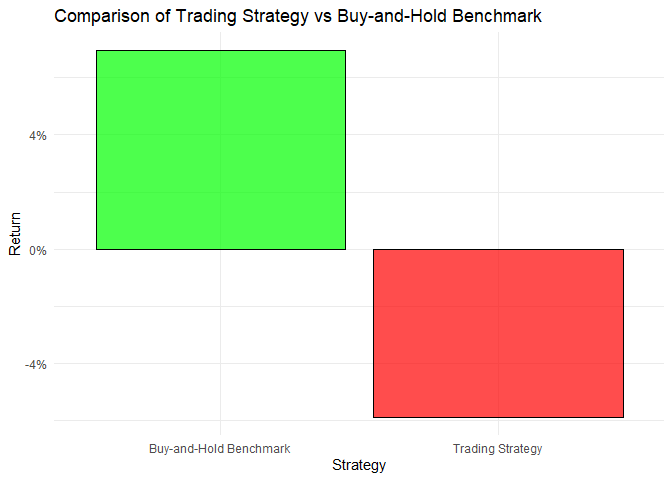

### 4.6 **Performance Analysis: Trading Strategy vs Buy-and-Hold Benchmark**

The results and visualization clearly show that the **trading strategy** significantly underperformed the **Buy-and-Hold benchmark**. The following is a detailed analysis and interpretation:

#### 4.6.1 **Trading Strategy Performance**

- **Cumulative Trading Strategy Return**: **-99.99%**
  - This indicates that the trading strategy almost completely wiped out the investment, leading to an extreme loss.
  - A return of **-99.99%** implies that the capital has been almost entirely depleted, leaving very little value.

#### 4.6.4 **Potential Causes of the Strategy’s Failure**

The catastrophic underperformance of the strategy may be attributed to several factors: 1. **Event Identification**: The threshold for significant price movements (e.g., -5%) might have led to frequent trades in stocks that were in a prolonged decline rather than capturing potential recoveries. 2. **Holding Period**: A holding period of 30 days may not have been enough to realize gains from rebounds or recoveries, or the market conditions may have continued to decline during that period. 3. **Execution Logic**: There may be flaws in the buy/sell price calculation, especially in how adjusted closing prices or lagged values were incorporated, which could have distorted the performance. 4. **Market Conditions**: A generally bearish or volatile market during the evaluation period may have exacerbated losses, amplifying the underperformance of the strategy.

## 5 **Re-implementation of the Trading Strategy with ARIMA**

**Recommendations for Improvement**

To improve the trading strategy’s performance:

1. **Refine the Strategy**:
   - Adjust thresholds for significant price drops and entry rules based on market trends.
   - Experiment with different holding periods.
2. **Introduce Stop-Loss Logic**:
   - Implement stop-loss mechanisms to manage risk and prevent large losses.
3. **Validate Data**:
   - Ensure data accuracy and correct reflection of market conditions.
4. **Backtest the Strategy**:
   - Test across various time periods and market conditions to assess robustness.

**Incorporating ARIMA into the Strategy**

To enhance the **3-Day Rule** strategy:

- After identifying a significant drop (≥ 5%), instead of buying immediately, we use the **ARIMA model** to predict future price movements.
- If ARIMA predicts a price increase with high confidence (e.g., 60-70%), we proceed with the purchase.
- We may also explore other models like **Random Forest** or **LSTM** for predictions.

**Real-Time Forecasting on the Day of the Event**

- On the day of the event, the ARIMA model will be used to forecast stock movement and decide whether to buy, improving timing and decision-making.

By integrating **ARIMA forecasting**, we aim to improve the accuracy of buy decisions and enhance overall strategy performance.

### 5.1 **Start of Implementation: Identifying True Events where a -5% Downturn is Identified**

We identify potential buying opportunities following a market correction of at least -5%.

**Click to see true events for UBS**

```
## [1] "NA"         "2022-02-24" "2022-03-01" "2022-03-04" "2022-06-16"
## [6] "2022-07-26" "2023-03-13" "2023-03-15" "2024-08-02"
```

### 5.2 **ARIMA Forecasting for a Specific Date**

Next, we use the ARIMA model to forecast future stock prices starting from a specific date. The forecast includes the predicted prices and the confidence intervals for future values.

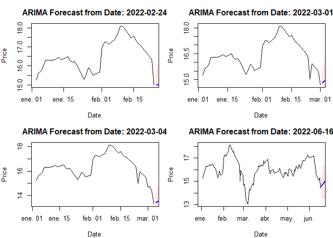

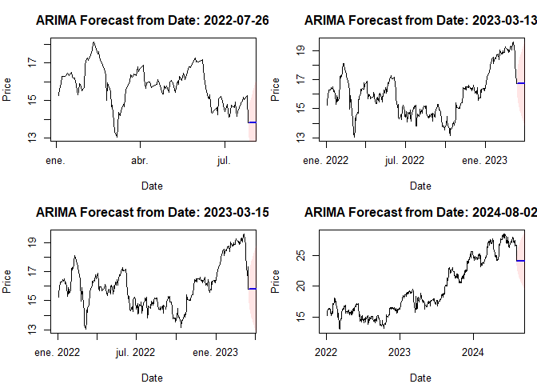

### 5.3 **Buy Decision Based on ARIMA Forecast**

Now, we implement a strategy where a stock is purchased based on ARIMA forecasts. If the forecast predicts an increase in the stock price beyond a certain threshold, the buy decision is marked as TRUE.

**Click to see ARIMA fit and evaluation functions**

```r
# Function to fit ARIMA model and make predictions
fit_arima_predict <- function(stock_data, symbol, periods = 30) {
  if (!is.null(stock_data[[symbol]])) {
    stock <- stock_data[[symbol]]
    adjusted_col <- paste0(symbol, ".Adjusted")

    # Check if the adjusted price column exists
    if (adjusted_col %in% colnames(stock)) {
      # Create a time series object
      ts_data <- ts(stock[, adjusted_col], frequency = 252)  # Assuming daily data (252 trading days)

      # Fit ARIMA model
      arima_model <- auto.arima(ts_data)

      # Forecast future prices (for the next `periods` days)
      forecast_result <- forecast(arima_model, h = periods)

      return(forecast_result)
    } else {
      cat("Adjusted price column not found for:", symbol, "\n")
      return(NULL)
    }
  } else {
    cat("No data available for:", symbol, "\n")
    return(NULL)
  }
}

# Function to evaluate ARIMA forecast and decide whether to buy
evaluate_arima_buy <- function(forecast_result, threshold = 0.6) {
  if (!is.null(forecast_result)) {
    # Check if the predicted price for the next day shows an increase (compared to the last observed price)
    forecast_values <- forecast_result$mean
    current_price <- tail(forecast_result$x, 1)  # Last observed price
    forecast_increase <- (forecast_values[1] - current_price) / current_price  # Percentage change for the next day

    # If the predicted increase is above the threshold, we set Buy_Decision to TRUE
    if (forecast_increase >= threshold) {
      return(TRUE)
    }
  }

  return(FALSE)
}
```

### 5.4 **Adding Buy Decision Column - ARIMA**

We apply the ARIMA-based buy decision strategy to the dataset by adding a new column, Buy_Decision, which is set to TRUE if the ARIMA forecast indicates a buy opportunity.

**Click to see buy decisions**

```
## Processing symbol: ABBN.SW
## Processing symbol: ADEN.SW
## Processing symbol: ALC.SW
## Processing symbol: CFR.SW
## Processing symbol: GEBN.SW
## Processing symbol: GIVN.SW
## Processing symbol: HOLN.SW
## Processing symbol: BAER.SW
## Processing symbol: KNIN.SW
## Processing symbol: LOGN.SW
## Processing symbol: LONN.SW
## Processing symbol: NESN.SW
## Processing symbol: NOVN.SW
## Processing symbol: PGHN.SW
## Processing symbol: ROG.SW
## Processing symbol: SIKA.SW
## Processing symbol: SOON.SW
## Processing symbol: SLHN.SW
## Processing symbol: SREN.SW
## Processing symbol: SCMN.SW
## Processing symbol: UHR.SW
## Processing symbol: UBSG.SW
## Processing symbol: ZURN.SW
```

### 5.5 **Adding Buy Dates - ARIMA**

Therefore we implement the ARIMA-based buy decision strategy by adding a new column, Buy_Decision, which is marked as TRUE if the ARIMA forecast indicates a buy opportunity.

**Click to see buy dates**

[output not shown]

[output cut: 51878 more lines]

```
## 2024-11-29     <NA>
## 2024-12-02     <NA>
## 2024-12-03     <NA>
## 2024-12-04     <NA>
## 2024-12-05     <NA>
## 2024-12-06     <NA>
## 2024-12-09     <NA>
## 2024-12-10     <NA>
## 2024-12-11     <NA>
## 2024-12-12     <NA>
## 2024-12-13     <NA>
## 2024-12-16     <NA>
## 2024-12-17     <NA>
## 2024-12-18     <NA>
## 2024-12-19     <NA>
```

```
##            Event_Date Buy_Date Buy_Decision
## 2022-01-03 2022-01-03     <NA>        FALSE
## 2022-01-04 2022-01-04     <NA>        FALSE
## 2022-01-05 2022-01-05     <NA>        FALSE
## 2022-01-06 2022-01-06     <NA>        FALSE
## 2022-01-07 2022-01-07     <NA>        FALSE
## 2022-01-10 2022-01-10     <NA>        FALSE
## 2022-01-11 2022-01-11     <NA>        FALSE
## 2022-01-12 2022-01-12     <NA>        FALSE
## 2022-01-13 2022-01-13     <NA>        FALSE
## 2022-01-14 2022-01-14     <NA>        FALSE
## 2022-01-17 2022-01-17     <NA>        FALSE
## 2022-01-18 2022-01-18     <NA>        FALSE
## 2022-01-19 2022-01-19     <NA>        FALSE
## 2022-01-20 2022-01-20     <NA>        FALSE
## 2022-01-21 2022-01-21     <NA>        FALSE
## 2022-01-24 2022-01-24     <NA>        FALSE
## 2022-01-25 2022-01-25     <NA>        FALSE
## 2022-01-26 2022-01-26     <NA>        FALSE
## 2022-01-27 2022-01-27     <NA>        FALSE
## 2022-01-28 2022-01-28     <NA>        FALSE
## 2022-01-31 2022-01-31     <NA>        FALSE
## 2022-02-01 2022-02-01     <NA>        FALSE
## 2022-02-02 2022-02-02     <NA>        FALSE
## 2022-02-03 2022-02-03     <NA>        FALSE
## 2022-02-04 2022-02-04     <NA>        FALSE
## 2022-02-07 2022-02-07     <NA>        FALSE
## 2022-02-08 2022-02-08     <NA>        FALSE
## 2022-02-09 2022-02-09     <NA>        FALSE
## 2022-02-10 2022-02-10     <NA>        FALSE
## 2022-02-11 2022-02-11     <NA>        FALSE
## 2022-02-14 2022-02-14     <NA>        FALSE
## 2022-02-15 2022-02-15     <NA>        FALSE
## 2022-02-16 2022-02-16     <NA>        FALSE
## 2022-02-17 2022-02-17     <NA>        FALSE
## 2022-02-18 2022-02-18     <NA>        FALSE
## 2022-02-21 2022-02-21     <NA>        FALSE
## 2022-02-22 2022-02-22     <NA>        FALSE
## 2022-02-23 2022-02-23     <NA>        FALSE
## 2022-02-24 2022-02-24     <NA>        FALSE
```

[output cut: 46 more lines]

```
## 2022-05-04 2022-05-04     <NA>        FALSE
## 2022-05-05 2022-05-05     <NA>        FALSE
## 2022-05-06 2022-05-06     <NA>        FALSE
## 2022-05-09 2022-05-09     <NA>        FALSE
## 2022-05-10 2022-05-10     <NA>        FALSE
## 2022-05-11 2022-05-11     <NA>        FALSE
## 2022-05-12 2022-05-12     <NA>        FALSE
## 2022-05-13 2022-05-13     <NA>        FALSE
## 2022-05-16 2022-05-16     <NA>        FALSE
## 2022-05-17 2022-05-17     <NA>        FALSE
## 2022-05-18 2022-05-18     <NA>        FALSE
## 2022-05-19 2022-05-19     <NA>        FALSE
## 2022-05-20 2022-05-20     <NA>        FALSE
## 2022-05-23 2022-05-23     <NA>        FALSE
## 2022-05-24 2022-05-24     <NA>        FALSE
```

### 5.6 **Holding the Stock for 30 Days & Calculate Returns - ARIMA**

As in the previous approach, after purchasing the stock, it is held for 30 trading days to allow for potential recovery from any initial market overreaction.

**Click to see holding period**

```
##            UBSG.SW.Open UBSG.SW.High UBSG.SW.Low UBSG.SW.Close UBSG.SW.Volume
## 2022-01-03       16.425       16.650      16.380        16.630        4570356
## 2022-01-04       16.700       17.095      16.700        17.040        9988997
## 2022-01-05       17.060       17.160      17.000        17.150        6879678
## 2022-01-06       17.060       17.425      16.970        17.340       11622944
## 2022-01-07       17.500       17.875      17.465        17.780       15152280
## 2022-01-10       17.840       17.960      17.625        17.780       10876949
## 2022-01-11       17.830       17.925      17.730        17.820        8193928
## 2022-01-12       17.895       17.975      17.700        17.870        8162261
## 2022-01-13       17.830       18.000      17.815        17.940        5993146
## 2022-01-14       17.820       17.980      17.720        17.815        6290114
## 2022-01-17       17.885       17.990      17.870        17.980        6323774
## 2022-01-18       17.880       17.945      17.725        17.750        8239961
## 2022-01-19       17.730       17.840      17.575        17.660        7293279
## 2022-01-20       17.550       17.725      17.505        17.680        6547998
## 2022-01-21       17.440       17.715      17.375        17.490       12795643
## 2022-01-24       17.570       17.570      16.575        16.670       13021542
## 2022-01-25       16.750       17.060      16.670        16.930       10147253
## 2022-01-26       17.050       17.500      17.045        17.345        7017701
## 2022-01-27       17.180       17.460      17.100        17.215        9858531
## 2022-01-28       17.230       17.265      16.705        16.935        9976661
## 2022-01-31       17.150       17.285      17.030        17.100       12006326
## 2022-02-01       18.050       18.475      17.960        18.475       23528059
## 2022-02-02       18.500       18.930      18.455        18.800       19878444
## 2022-02-03       18.830       19.100      18.750        18.830       14798979
## 2022-02-04       18.900       18.985      18.455        18.690       10302209
## 2022-02-07       18.755       19.005      18.645        19.005       11354111
## 2022-02-08       19.020       19.335      19.010        19.300       12372440
## 2022-02-09       19.400       19.790      19.305        19.720       13024990
## 2022-02-10       19.520       19.900      19.510        19.750       14427270
## 2022-02-11       19.465       19.735      19.420        19.610       10909790
## 2022-02-14       19.040       19.165      18.800        19.065       13577591
## 2022-02-15       18.700       19.225      18.555        19.175       10354149
## 2022-02-16       19.300       19.340      18.705        18.925        9755735
## 2022-02-17       18.900       18.935      18.580        18.740        9238626
## 2022-02-18       18.725       18.890      18.595        18.650       10102466
## 2022-02-21       18.620       18.785      18.065        18.170        8574739
## 2022-02-22       17.585       18.185      17.300        18.020       14867844
## 2022-02-23       18.090       18.205      17.805        17.815        8327922
## 2022-02-24       16.885       17.100      16.065        16.350       24469646
```

[output cut: 248 more lines]

```
## 2022-05-04     <NA>     NA
## 2022-05-05     <NA>     NA
## 2022-05-06     <NA>     NA
## 2022-05-09     <NA>     NA
## 2022-05-10     <NA>     NA
## 2022-05-11     <NA>     NA
## 2022-05-12     <NA>     NA
## 2022-05-13     <NA>     NA
## 2022-05-16     <NA>     NA
## 2022-05-17     <NA>     NA
## 2022-05-18     <NA>     NA
## 2022-05-19     <NA>     NA
## 2022-05-20     <NA>     NA
## 2022-05-23     <NA>     NA
## 2022-05-24     <NA>     NA
```

### 5.7 ** Calculate Summary of the Results**

The performance of the strategy is quantified using several key metrics:

- **Average Return**: The average return across all transactions.
- **Median Return**: The median return, which helps avoid distortion due to outliers.
- **Positive vs. Negative Returns**: The proportion of positive returns relative to negative returns.
- **Maximum and Minimum Return**: Identification of the maximum and minimum returns across the trades.
- **Total Return**: The total return when applying the strategy to the entire portfolio.

**Click to see arima results**

```
## $average_return
## [1] -0.1423139
##
## $median_return
## [1] -0.1024356
##
## $positive_ratio
## [1] 0
##
## $max_return
## [1] -0.0049905
##
## $min_return
## [1] -0.3586576
##
## $total_return
## [1] -0.8538837
```

#### 5.7.1 **Comparing Trading Strategy with Buy-and-Hold and ARIMA**

We now compare the performance of the trading strategy with a Buy-and-Hold benchmark and an ARIMA-based strategy.

**Click to see results**

```
## Average Benchmark (Buy-and-Hold) Return: 6.934833 %
```

```
## Average Trading Strategy Return: -5.870574 %
```

```
## Cumulative Trading Strategy Return: -99.98616 %
```

```
## Average ARIMA Strategy Return: -14.23139 %
```

```
## Cumulative ARIMA Strategy Return: -62.47956 %
```

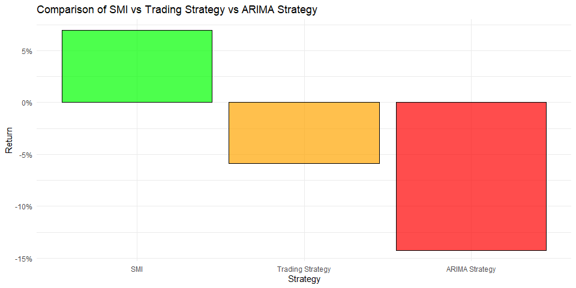

## 6 **Conclusion**

### 6.2 **Next Steps**

- **Refinement of Active Strategies**: Both **Trading** and **ARIMA strategies** need optimization, including adjusting entry/exit points, time horizons, and thresholds for better market responsiveness.
- **Risk Management**: Incorporating tools like **stop-loss orders** can help mitigate losses during market volatility, preserving capital.
- **Exploration of Alternative Models**: Using advanced techniques like **Random Forests**, **Gradient Boosting**, or **LSTM** could enhance predictive accuracy by identifying complex data patterns that simpler models might miss.

In conclusion, while **Barney’s 3-Day Rule** might be useful in some contexts, our analysis suggests that **a more thoughtful, data-driven approach** may be needed in the realm of stock trading. Long-term strategies with better risk management could provide more stable returns, while the active strategies would benefit from a more refined and evidence-based approach.

As with life, not every investment is a quick win. **Maybe a stock, like a person, isn’t something to hold onto for just a month.** Some things, and people, are meant to become part of our lives and families, requiring more time and patience. So, while **Barney’s 3-Day Rule** might work for quick decisions, perhaps, for stocks (and relationships), we should consider a longer-term commitment.

Let’s keep refining the strategy, try out different models, and who knows? Maybe next time we’ll make better choices, both with stocks and in life.

## 7 **Usage of Gen AI in the Project**

Throughout this project, **Gen AI** played a crucial role in improving our analysis and decision-making for the strategy. It assisted in the development of forecasting models by suggesting improvements to existing algorithms, particularly in identifying and refining entry points for both the **Trading Strategy** and **ARIMA Strategy**. Gen AI also provided valuable insights into alternative strategies, offering recommendations on more advanced techniques, such as **Random Forest** and **LSTM**, which could potentially improve prediction accuracy, but where out of scope.

Moreover, **Gen AI** was used to optimize code and streamline the process of backtesting strategies, saving significant time and effort.

**THANK YOU!**

[figure not shown]